# POLI 572B

Michael Weaver

March 9, 2020

# Inference with Least Squares

### Objectives

**Recap**

- Ordinary Least Squares assumptions for inference

**Causal Inference with Regression**

- Omitted Variable Bias (link to conditioning)
- Interpolation/Extrapolation Bias
- Conditioning in Regression

# Recap

### Ordinary Least Squares Assumptions:

1. $Y$ is generated by $\mathbf{X\beta} + \epsilon$ (**model** equation is correct)
2. $\epsilon_i$ are independent, identically distributed, with variance $\sigma^2$ for *all* $i$
3. $X_i \perp \!\!\! \perp \epsilon_i$: $X_i$ is **independent** of $\epsilon_i$

If these assumptions are true:

- OLS $\widehat{\beta}$ is **unbiased** estimator for $\beta$
- known sampling distribution of $\widehat{\beta}$

# A Causal Model for Least Squares

### Response Schedule

In the context of **experiments**, each observation has potential outcomes corresponding to their behavior under different treatments

- To estimate $ACE$ of treatment without bias, assumed that treatment status is **independent** of potential outcomes

### Response Schedule

In regression, where levels of treatment might be continuous, we generalize this idea to the “response schedule”:

- some equation that reflects potential outcomes across different values of the “treatment”

### Response Schedule

$$Y(D_i = d) = \beta_0 + \beta_1 D_i + \epsilon_i$$

Here $Y_i(D_i = d)$ is the potential outcome for $i$ for a value of $D = d$.

- this response schedule says that $Y_i$ changes same amount for all unit changes in $D$ (or an average across non-linear effects of $D$)
- We only ever observe one $Y_i(D_i = d)$ for the $d$ that occurs, others are counterfactual.

### Response Schedule

If we don’t know parameters $\beta_0, \beta_1$, what do we need to assume to obtain an estimate $\widehat{\beta}_1$ that we can give a **causal** interpretation? (On average, change in $D$ **causes** $\widehat{\beta}_1$ change in $Y$)

**We must assume**

- $Y_i$ actually produced according to the response schedule (equation is correctly specified; e.g., linear and additive)
- $D_i$ is independent of $\epsilon_i$: $D_i \perp \!\!\! \perp \epsilon_i$. Sometimes we say $D$ is **exogenous**

### Response Schedule

Recall OLS assumptions: to have no bias…

- $D$ independent of $\epsilon$
- and $\epsilon$ are other variables that **affect** $Y$, per the model.

What is one way to be sure we can find effect of $D$ without bias?

- $D$ randomly assigned

### But assumptions are violated

If the true process generating the data is:

$$Y_i = \beta_0 + \beta_1 D_i + \beta_2 X_i + \epsilon_i$$

with $(D_i,X_i) \perp \!\!\! \perp \epsilon_i$, $E(\epsilon_i) = 0$, $Var(\epsilon_i) = \sigma^2$

What happens when we estimate this model with a constant and $D_i$ but exclude $X_i$?

$$Y_i = \beta_0 + \beta_1 D_i + \epsilon_i$$

$$\small\begin{eqnarray}
\widehat{\beta_1} &=& \frac{Cov(D_i, Y_i)}{Var(D_i)} \\
&=& \frac{Cov(D_i, \beta_0 + \beta_1 D_i + \beta_2 X_i + \epsilon_i)}{Var(D_i)} \\
&=& \frac{Cov(D_i, \beta_1 D_i)}{Var(D_i)} + \frac{Cov(D_i,\beta_2 X_i)}{Var(D_i)} + \frac{Cov(D_i,\epsilon_i)}{Var(D_i)} \\
&=& \beta_1\frac{Var(D_i)}{Var(D_i)} + \beta_2\frac{Cov(D_i, X_i)}{Var(D_i)} \\
&=& \beta_1 + \beta_2\frac{Cov(D_i, X_i)}{Var(D_i)}
\end{eqnarray}$$

So, $E(\widehat{\beta_1}) \neq \beta_1$, it is **biased**

### Omitted Variable Bias

When we exclude $X_i$ from the regression, we get:

$$\widehat{\beta_1} = \beta_1 + \beta_2\frac{Cov(D_i, X_i)}{Var(D_i)}$$

This is **omitted variable bias**

Excluding $X$ from the model: $\widehat{\beta_1} = \beta_1 + \beta_2\frac{Cov(D_i, X_i)}{Var(D_i)}$

What is the direction of the bias when:

1. $\beta_2 > 0$; $\frac{Cov(D_i, X_i)}{Var(D_i)} < 0$
2. $\beta_2 < 0$; $\frac{Cov(D_i, X_i)}{Var(D_i)} < 0$
3. $\beta_2 > 0$; $\frac{Cov(D_i, X_i)}{Var(D_i)} > 0$
4. $\beta_2 = 0$; $\frac{Cov(D_i, X_i)}{Var(D_i)} > 0$
5. $\beta_2 > 0$; $\frac{Cov(D_i, X_i)}{Var(D_i)} = 0$

### Omitted Variable Bias

This only yields bias if two conditions are true:

1. $\beta_2 \neq 0$: omitted variable $X$ has (or is correlated with something that has) an effect on $Y$
2. $\frac{Cov(D_i, X_i)}{Var(D_i)} \neq 0$: omitted variable $X$ is correlated with $D$.

This is why we don’t need to include EVERYTHING that might affect $Y$ in our regression equation; **only those variables that affect treatment and the outcome.**

### Conditioning:

**conditioning** is when we examine the effect of $D_i$ on $Y_i$ *within subsets/strata* of the data defined by the values of $\mathbf{X_i}$, **blocking** backdoor (non-causal) paths from $D$ to $Y$.

- Where $\mathbf{X_i}$ is a set of variables on backdoor paths from $D$ to $Y$.
- We examine relationship between $D$ and $Y$, within groups of cases where values of $\mathbf{X_i}$ are the same (hold value of backdoor paths constant)

### Conditioning Assumptions

$1$. **Ignorability**/**Conditional Independence**: within strata of $X$, potential outcomes of $Y$ must be **independent** of $D$ - all ‘backdoor’ paths are blocked; no colliders

$2$. **Positivity**/**Common Support**: For **all** values of treatment $d$ in $D$ and all value of $x$ in $X$: $Pr(D = d | X = x) > 0$ and $Pr(D = d | X = x) < 1$ - There must be variation in treatment **within every strata** of $X$

### Omitted Variable Bias

Link to DAGs:

- OVB solved when we “block” backdoor paths from $D$ to $Y$.

Link to conditioning:

- OVB is a result of conditional independence assumption being wrong

Link to OLS assumptions…

### Exercise:

1. Brainstorm an exhaustive list of variables that are causally linked to contracting COVID-19
2. Add these other variables (and any possible backdoor paths) to a DAG that initially includes just this link $\mathrm{Using \ Hand \ Sanitizer} \xrightarrow{Decreases} \mathrm{Pr(COVID)}$
3. Imagine we want to estimate the causal effect of sanitizer usage on contracting COVID-19:
   - which of the variables in your DAG would produce OVB if excluded from the regression?
   - which of the variables in your DAG WOULD NOT produce OVB?

# Other Biases

### (1) Omitted Variable Bias

- Excluding some variable $X$ that should be in the model
- Induces bias if $X$ is causally related to both $D$ and $Y$ ($X$ is a confounder)
- We need to make a big assumption that we’ve included all relevant confounding variables: **conditional independence assumption** or **ignorability**

### Potential Pitfalls

Even if we included **all** variables on backdoor path between $D$ and $Y$, we could have problems getting an unbiased estimate of the causal effect using regression:

- we typically assume the model is linear and additive.
- but the world might be non-linear and interactive (effect of $D$ on $Y$ depends on $Z$)
- our decisions about how to specify the math of regression equation can lead to bias

### (2) Interpolation Bias:

Typically: we approximate the relationship between variables in $X$ and $D$ to be additive and linear. If linear approximation is wrong, we have bias.

- By forcing relationship between $X$ (and for generality $X_1 \ldots X_k$) and $D$ to be linear and additive, conditioning on $X$ may not remove non-linear association between $X$ and $D$, $X$ and $Y$. $\to$ bias.
- This unmodeled relationship will become part of $\epsilon_i$ (because $X$ affects $Y$), and will not be independent of $D_i$ (because there is a non-linear association between $X$ and $D$).

### Example: Interpolation

Let’s say the **model** we want to estimate is:

$Y_i = \beta_0 + \beta_1 Hours_i + \beta_2 Female_i +$ $\beta_3 Age_i + \beta_4 Law_i + \epsilon_i$

And we want to find $\beta_1$ with $\widehat{\beta_1}$

### Example: Interpolation

We can assume linearity and additivity:

```r
lm(INCEARN ~ UHRSWORK + SEX + AGE + LAW, data = acs_data) %>% summary
```

```
##
## Call:
## lm(formula = INCEARN ~ UHRSWORK + SEX + AGE + LAW, data = acs_data)
##
## Residuals:
##     Min      1Q  Median      3Q     Max
## -314852  -89604  -28382   71587 1065811
##
## Coefficients:
##              Estimate Std. Error t value Pr(>|t|)
## (Intercept)   3782.10    2295.92   1.647   0.0995 .
## UHRSWORK      1301.77      27.66  47.062   <2e-16 ***
## SEX         -40411.28     683.32 -59.140   <2e-16 ***
## AGE           3377.68      30.47 110.853   <2e-16 ***
## LAW         -48942.34     647.40 -75.598   <2e-16 ***
## ---
## Signif. codes:  0 '***' 0.001 '**' 0.01 '*' 0.05 '.' 0.1 ' ' 1
##
## Residual standard error: 126900 on 166839 degrees of freedom
## Multiple R-squared:  0.1506, Adjusted R-squared:  0.1506
## F-statistic:  7397 on 4 and 166839 DF,  p-value: < 2.2e-16
```

### Example: Interpolation

Questions to ask:

- Is relationship between age and hours, age and income earned **linear**?
- Are the effects of sex and age **additive**? (Relationship between age and hours worked the same for men and women?)

### Example: Interpolation

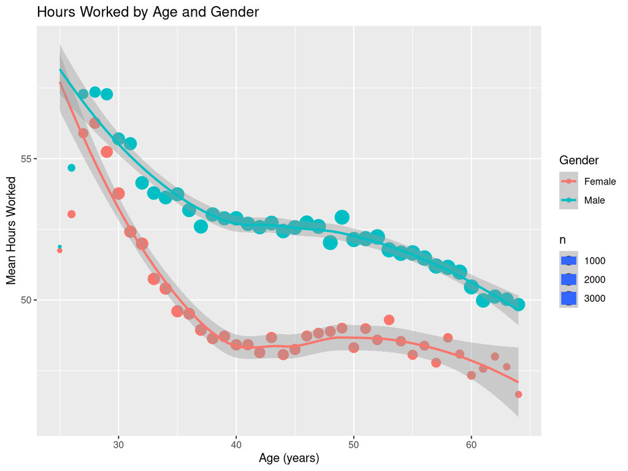

Assuming additivity and linearity:

```r
lm(INCEARN ~ UHRSWORK + SEX + AGE + LAW, data = acs_data) %>% summary
```

```
##
## Call:
## lm(formula = INCEARN ~ UHRSWORK + SEX + AGE + LAW, data = acs_data)
##
## Residuals:
##     Min      1Q  Median      3Q     Max
## -314852  -89604  -28382   71587 1065811
##
## Coefficients:
##              Estimate Std. Error t value Pr(>|t|)
## (Intercept)   3782.10    2295.92   1.647   0.0995 .
## UHRSWORK      1301.77      27.66  47.062   <2e-16 ***
## SEX         -40411.28     683.32 -59.140   <2e-16 ***
## AGE           3377.68      30.47 110.853   <2e-16 ***
## LAW         -48942.34     647.40 -75.598   <2e-16 ***
## ---
## Signif. codes:  0 '***' 0.001 '**' 0.01 '*' 0.05 '.' 0.1 ' ' 1
##
## Residual standard error: 126900 on 166839 degrees of freedom
## Multiple R-squared:  0.1506, Adjusted R-squared:  0.1506
## F-statistic:  7397 on 4 and 166839 DF,  p-value: < 2.2e-16
```

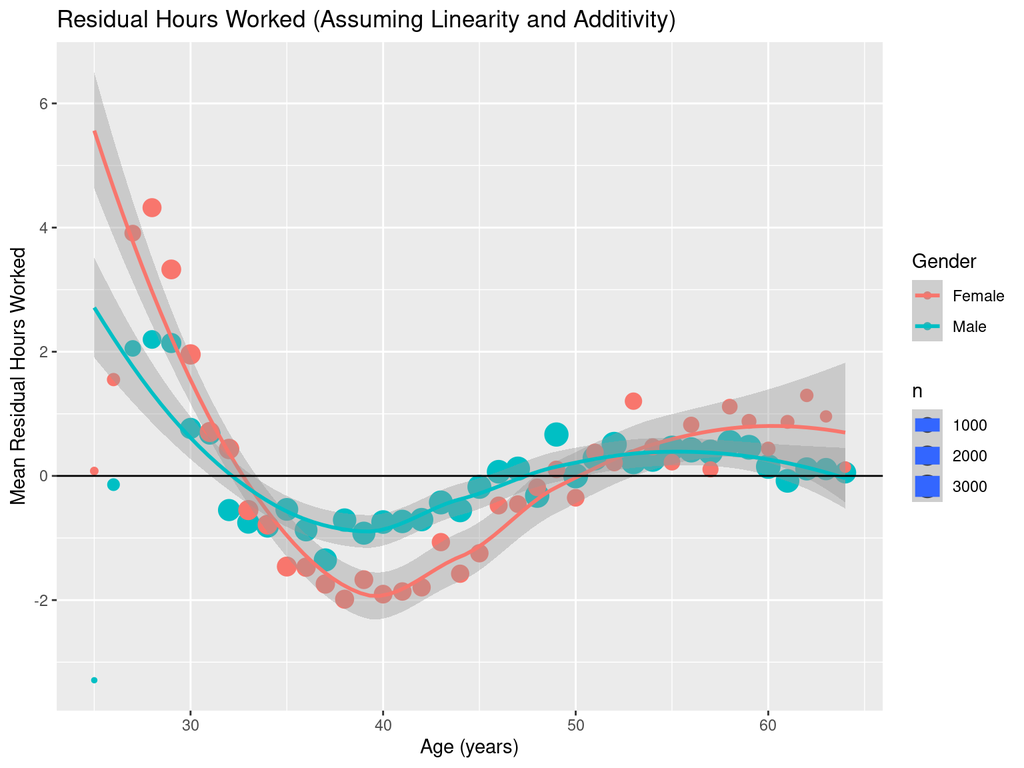

Assuming linearity, not additivity

```r
lm(INCEARN ~ UHRSWORK + SEX*AGE + LAW, data = acs_data) %>% summary
```

```
##
## Call:
## lm(formula = INCEARN ~ UHRSWORK + SEX * AGE + LAW, data = acs_data)
##
## Residuals:
##     Min      1Q  Median      3Q     Max
## -316004  -89725  -28458   71349 1064913
##
## Coefficients:
##              Estimate Std. Error t value Pr(>|t|)
## (Intercept)    358.37    2477.51   0.145 0.884988
## UHRSWORK      1300.22      27.66  47.002  < 2e-16 ***
## SEX         -29995.51    2914.29 -10.293  < 2e-16 ***
## AGE           3452.76      36.68  94.135  < 2e-16 ***
## LAW         -48949.01     647.38 -75.611  < 2e-16 ***
## SEX:AGE       -238.80      64.95  -3.677 0.000237 ***
## ---
## Signif. codes:  0 '***' 0.001 '**' 0.01 '*' 0.05 '.' 0.1 ' ' 1
##
## Residual standard error: 126900 on 166838 degrees of freedom
## Multiple R-squared:  0.1507, Adjusted R-squared:  0.1507
## F-statistic:  5920 on 5 and 166838 DF,  p-value: < 2.2e-16
```

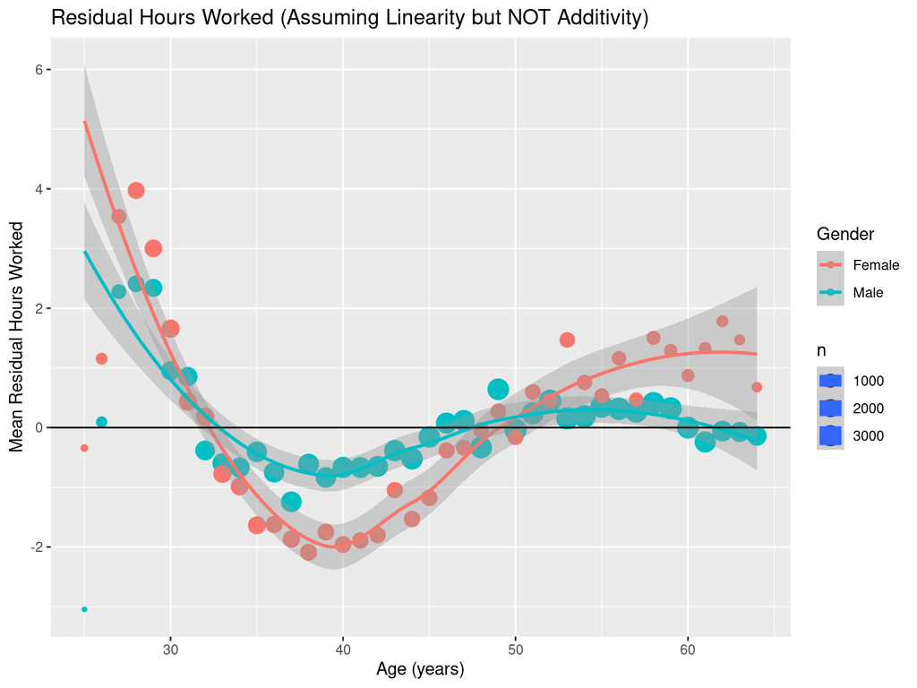

Assuming neither linearity or additivity

```r
lm(INCEARN ~ UHRSWORK + as.factor(SEX)*as.factor(AGE) + LAW, data = acs_data) %>% summary
```

```
##
## Call:
## lm(formula = INCEARN ~ UHRSWORK + as.factor(SEX) * as.factor(AGE) +
##     LAW, data = acs_data)
##
## Residuals:
##     Min      1Q  Median      3Q     Max
## -317309  -87614  -26776   70186 1085490
##
## Coefficients:
##                                   Estimate Std. Error t value Pr(>|t|)
## (Intercept)                       14471.10   11240.80   1.287 0.197966
## UHRSWORK                           1453.56      27.04  53.758  < 2e-16 ***
## as.factor(SEX)1                    -222.84   14509.56  -0.015 0.987746
## as.factor(AGE)26                   -227.22   12367.78  -0.018 0.985342
## as.factor(AGE)27                  -4093.90   11714.05  -0.349 0.726725
## as.factor(AGE)28                    857.74   11550.31   0.074 0.940803
## as.factor(AGE)29                   6050.51   11471.60   0.527 0.597893
## as.factor(AGE)30                  17439.54   11428.81   1.526 0.127030
## as.factor(AGE)31                  29153.11   11417.68   2.553 0.010671 *
## as.factor(AGE)32                  47053.94   11396.85   4.129 3.65e-05 ***
## as.factor(AGE)33                  65831.26   11393.78   5.778 7.58e-09 ***
## as.factor(AGE)34                  85911.22   11386.22   7.545 4.54e-14 ***
## as.factor(AGE)35                 101013.05   11376.88   8.879  < 2e-16 ***
## as.factor(AGE)36                 112628.62   11378.39   9.898  < 2e-16 ***
## as.factor(AGE)37                 125906.23   11367.24  11.076  < 2e-16 ***
## as.factor(AGE)38                 138508.50   11360.78  12.192  < 2e-16 ***
## as.factor(AGE)39                 148459.13   11369.87  13.057  < 2e-16 ***
## as.factor(AGE)40                 150215.80   11354.72  13.229  < 2e-16 ***
## as.factor(AGE)41                 155499.72   11359.63  13.689  < 2e-16 ***
## as.factor(AGE)42                 155370.17   11361.77  13.675  < 2e-16 ***
## as.factor(AGE)43                 161180.51   11347.70  14.204  < 2e-16 ***
## as.factor(AGE)44                 161984.26   11349.40  14.272  < 2e-16 ***
## as.factor(AGE)45                 171542.30   11348.39  15.116  < 2e-16 ***
## as.factor(AGE)46                 170424.45   11354.32  15.010  < 2e-16 ***
## as.factor(AGE)47                 172392.33   11342.30  15.199  < 2e-16 ***
## as.factor(AGE)48                 165000.71   11339.02  14.552  < 2e-16 ***
## as.factor(AGE)49                 168936.32   11341.20  14.896  < 2e-16 ***
## as.factor(AGE)50                 168572.39   11328.47  14.880  < 2e-16 ***
## as.factor(AGE)51                 167874.54   11331.84  14.814  < 2e-16 ***
```

[output cut: 44 more lines]

```
## as.factor(SEX)1:as.factor(AGE)56 -50530.06   15125.25  -3.341 0.000836 ***
## as.factor(SEX)1:as.factor(AGE)57 -53462.32   15142.56  -3.531 0.000415 ***
## as.factor(SEX)1:as.factor(AGE)58 -50651.21   15179.63  -3.337 0.000848 ***
## as.factor(SEX)1:as.factor(AGE)59 -46199.91   15263.25  -3.027 0.002471 **
## as.factor(SEX)1:as.factor(AGE)60 -40946.54   15317.89  -2.673 0.007516 **
## as.factor(SEX)1:as.factor(AGE)61 -41701.21   15414.78  -2.705 0.006826 **
## as.factor(SEX)1:as.factor(AGE)62 -49152.09   15505.31  -3.170 0.001525 **
## as.factor(SEX)1:as.factor(AGE)63 -51645.68   15757.81  -3.277 0.001048 **
## as.factor(SEX)1:as.factor(AGE)64 -47218.46   15938.36  -2.963 0.003051 **
## ---
## Signif. codes:  0 '***' 0.001 '**' 0.01 '*' 0.05 '.' 0.1 ' ' 1
##
## Residual standard error: 123500 on 166762 degrees of freedom
## Multiple R-squared:  0.1963, Adjusted R-squared:  0.1959
## F-statistic: 502.9 on 81 and 166762 DF,  p-value: < 2.2e-16
```

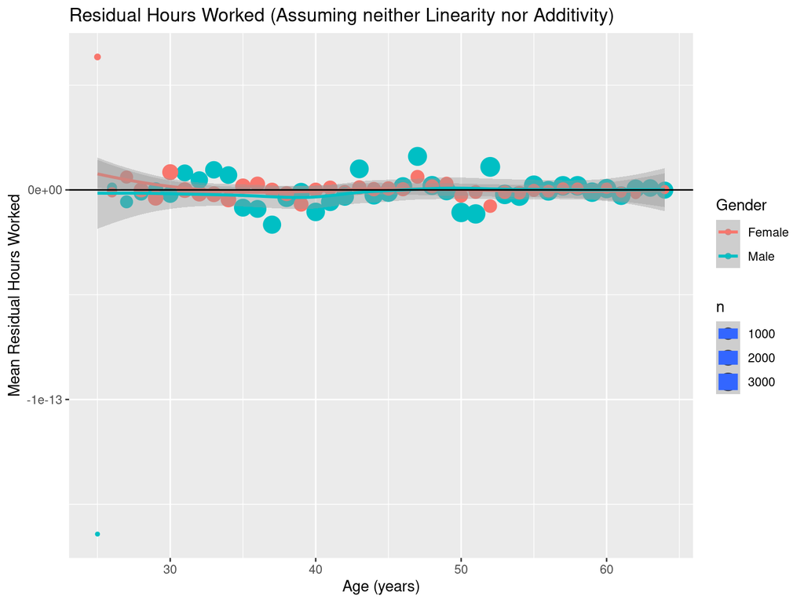

What is wrong with interpolation bias?

- In conditioning, we want to compare $Y_i(D_i = 1)|X_i$ to $Y_i(D_i = 0)|X_i$ for cases where values of confounding variables $X_i = x$ are the same
- In regression, we compare $Y_i(D_i = 1)|X_i$ against **linear prediction** of $\widehat{Y}(D_i = 0)|X_i$.
- This approximation may fail spectacularly…

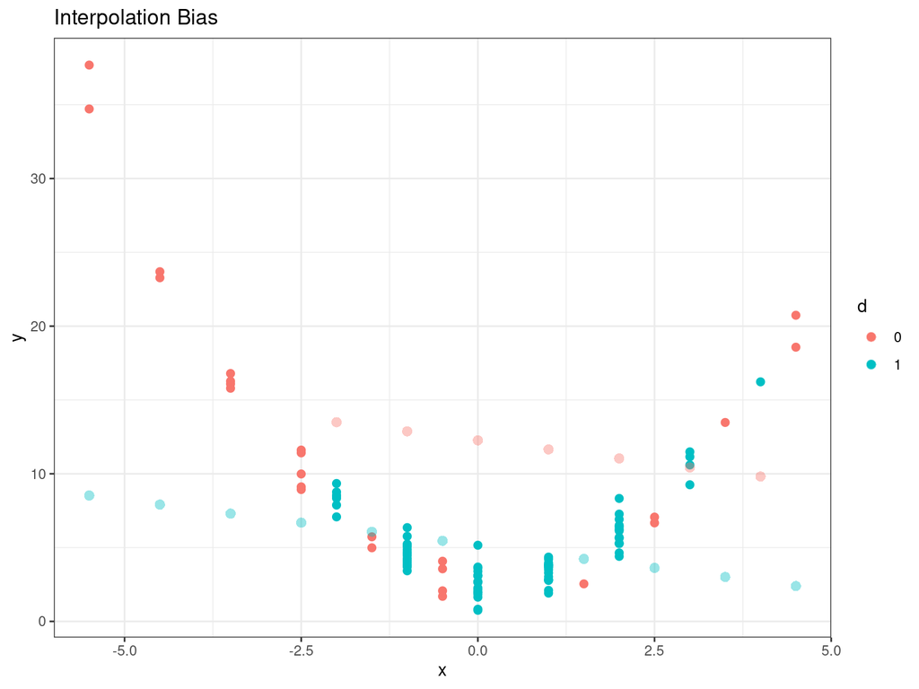

transparent dots indicate $\widehat{Y}$ interpolated by regression.

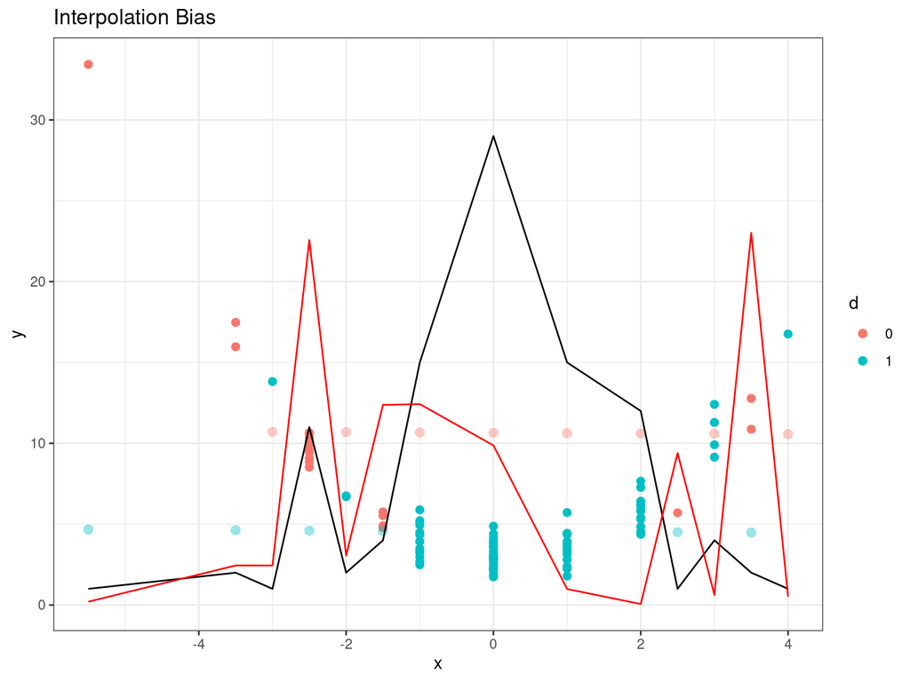

transparent dots indicate $\widehat{Y}$ interpolated by regression.

lines indicate relative weights

### Interpolation Bias:

When we **approximate** of the relationship of confounding variables $X$ with $D$ and $Y$ through **linearity** (or any imposed functional form) and **additivity**, we may generate **interpolation bias** even if there is no omitted variable bias.

Interpolation bias is relatively easy to diagnose:

- Scatterplot $D$ with $X$
- Choose more flexible model (non-linear/interactive)
- Linear/additive approximation may be acceptible because least squares is a linear apprx. of non-linear functions **within the region where we have data**.

### (3) Extrapolation Bias

Typically: we approximate the relationship between variables in $X$ and $D$ to be additive and linear.

If $D = 1$ never occurs for certain values of $X$ (e.g. $X > 0$), regression model will use additivity and linearity (or other functional form) to **extrapolate** a predicted value of what $D = 1$ would look like when $X > 0$.

- King and Zeng show that extrapolations are very **sensitive to model choice**: small changes in assumptions create large changes in estimates.

### Example: Extrapolation

Does being a democracy cause a country to provide better public goods?

We decide to estimate the following regression model. Let’s assume that there is no omitted variable bias.

$Public \ Goods_i = \beta_0 + \beta_1 Democracy_i +$ $\beta_2 ln(Per \ Capita \ GDP_i) + \epsilon_i$

Exercise: Download the simulated data from Canvas

$1$. Estimate $Public \ Goods_i = \beta_0 + \beta_1 Democracy_i + \beta_2 ln(Per \ Capita \ GDP_i) + \epsilon_i$ using the `lm` function. What is the effect of democracy on public goods? $2$. What does this model assume about the relationship between per capita GDP and public goods for democracies? For non-democracies? $3$. Plot public goods on GDP per capita, grouping by democracy: code on Google

In this example:

We observe no non-democracies with GDP per capita as high as some democracies, but must condition on GDP per capita.

Options

- Using regression ($1$ on previous slide): we linearly and additively **extrapolated** from the model what public goods for non-democracies with high per capita GDP would be (where we have no data, only the model)

or

### Conditioning and Regression:

Problems of extrapolation relate to assumption of **Positivity** or **Common Support** in conditioning:

- For conditioning: we assume that we have variation in $D$ within every strata of $X$.
- In regression, we may end up making model-based extrapolations…

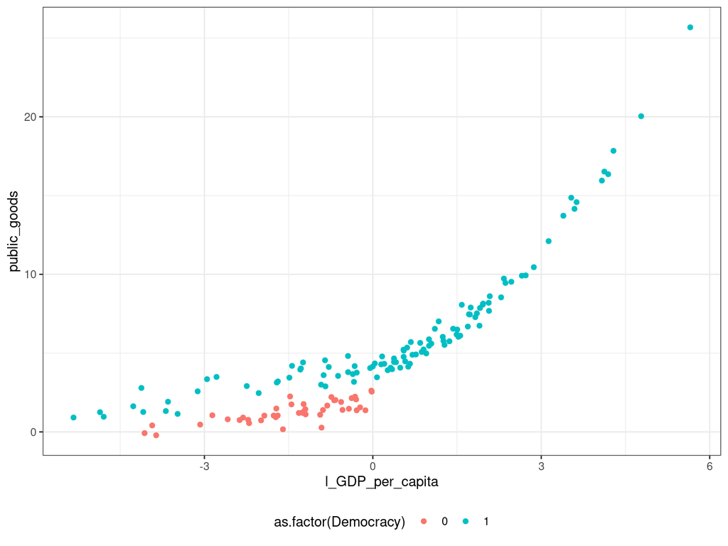

# Conditioning with Regression

### Inter/Extrapolation Bias

### Solutions?

- Restrict analyses to cases where we have overlap in conditioning variables (extrapolation)
- Fewer functional form assumptions (interpolation)

### Saturated Regression

One solution to both **extrapolation** and **interpolation** bias is **saturated regression**

- a dummy variable for **every** unique combination of values for conditioning variables $X$.
- we now compare difference in averages of treated/untreated **within** each strata of $X$
- returns **an** average causal effect, but weighted by size and **variance** of $D$ within each strata of $X$.

### Saturated Regression

Pros:

- no possibility of **interpolation**: model is linear and additive in $X$, but no need to make assumptions because we allow for all unique values of $X$ to have their own means.
- zero weight on strata of $X$ with all “treatment”/all “control” (no **extrapolation**)

### Saturated Regression

Gender bias in earnings: linear conditioning

```r
controls_linear = lm(INCEARN ~ FEMALE + AGE + RACE_f +
             EDUC_f + UHRSWORK + WKSWORK2 +
             LAW + MARST_f, acs_data)

summary(controls_linear)$coefficients
```

```
##                Estimate   Std. Error    t value      Pr(>|t|)
## (Intercept) 2626417.354 116837.67316  22.479199 9.731352e-112
## FEMALE       -35424.947    687.33004 -51.539937  0.000000e+00
## AGE            3108.872     31.85807  97.585063  0.000000e+00
## RACE_f        -1169.041    191.64782  -6.099946  1.063366e-09
## EDUC_f       -22801.479   1014.54598 -22.474564 1.079869e-111
## UHRSWORK       1311.048     27.49458  47.683876  0.000000e+00
## WKSWORK2       3824.380    775.09684   4.934067  8.061226e-07
## LAW          -49695.438    663.92667 -74.850793  0.000000e+00
## MARST_f2     -36919.833   2608.79684 -14.152054  1.927245e-45
## MARST_f3     -13734.075   3120.87422  -4.400714  1.079620e-05
## MARST_f4     -25045.597   1248.05771 -20.067659  1.805921e-89
## MARST_f5     -34930.941   4075.78689  -8.570355  1.040263e-17
## MARST_f6     -38621.940    926.38141 -41.691186  0.000000e+00
```

### Saturated Regression

dummy `saturated` = “AGE:RACE_f:EDUC_f:UHRSWORK:WKSWORK2:LAW:MARST_f”

| INCEARN | FEMALE | saturated |
| --- | --- | --- |
| 50000 | 0 | 25:1:115:35:6:1:6 |
| 45000 | 1 | 25:1:115:35:6:1:6 |
| 24000 | 1 | 25:1:115:35:6:1:6 |
| 24100 | 1 | 25:1:115:40:4:1:6 |
| 30000 | 1 | 25:1:115:40:4:1:6 |
| 30000 | 0 | 25:1:115:40:4:1:6 |
| 15000 | 1 | 25:1:115:40:4:1:6 |
| 10000 | 1 | 25:1:115:40:4:1:6 |
| 34000 | 0 | 25:1:115:40:4:1:6 |
| 25000 | 1 | 25:1:115:40:4:1:6 |

### Saturated Regression

Gender bias in earnings: saturated regression

```r
require(lfe)
#felm(y ~ x1 + x2 | fixed_effect | instrument | cluster, data = ___)
controls_saturated = felm(INCEARN ~ FEMALE | saturated | 0 | 0, acs_data)

#Saturated
summary(controls_saturated)$coefficients
```

```
##         Estimate Std. Error   t value Pr(>|t|)
## FEMALE -30458.03   721.0478 -42.24135        0
```

```r
#Linear
summary(controls_linear)$coefficients
```

```
##                Estimate   Std. Error    t value      Pr(>|t|)
## (Intercept) 2626417.354 116837.67316  22.479199 9.731352e-112
## FEMALE       -35424.947    687.33004 -51.539937  0.000000e+00
## AGE            3108.872     31.85807  97.585063  0.000000e+00
## RACE_f        -1169.041    191.64782  -6.099946  1.063366e-09
## EDUC_f       -22801.479   1014.54598 -22.474564 1.079869e-111
## UHRSWORK       1311.048     27.49458  47.683876  0.000000e+00
## WKSWORK2       3824.380    775.09684   4.934067  8.061226e-07
## LAW          -49695.438    663.92667 -74.850793  0.000000e+00
## MARST_f2     -36919.833   2608.79684 -14.152054  1.927245e-45
## MARST_f3     -13734.075   3120.87422  -4.400714  1.079620e-05
## MARST_f4     -25045.597   1248.05771 -20.067659  1.805921e-89
## MARST_f5     -34930.941   4075.78689  -8.570355  1.040263e-17
## MARST_f6     -38621.940    926.38141 -41.691186  0.000000e+00
```

### Saturated Regression

We can use conditioning without **interpolation** bias, **extrapolation** bias, but

- we are still make conditional independence assumption
- saturated regression suffers from **curse of dimensionality** (a lot of $N$ needed, usually)
- returns a variance-weighted effect, may not be what we want (this is fixable, though)